# 消費者態度の形成メカニズムのモデル化

## 練習問題

### データ

|  | CE1 | CE2 | CE3 | PQ1 | PQ2 | PQ3 | CS1 | CS2 | CS3 |
| --- | --- | --- | --- | --- | --- | --- | --- | --- | --- |
| 1 | 5 | 5 | 6 | 4 | 6 | 5 | 5 | 4 | 4 |
| 2 | 6 | 6 | 6 | 3 | 2 | 1 | 2 | 2 | 2 |
| 3 | 3 | 4 | 4 | 5 | 5 | 6 | 7 | 7 | 5 |
| 4 | 4 | 4 | 4 | 4 | 5 | 5 | 5 | 5 | 4 |
| 5 | 3 | 3 | 6 | 2 | 2 | 2 | 2 | 2 | 4 |
| 6 | 1 | 1 | 1 | 1 | 1 | 1 | 1 | 1 | 1 |

**大学生への大学満足度アンケート (n = 41)** → [data_csi.csv](https://drive.google.com/open?id=1ZoEsSX6KC9vxWmaN5DYdh3In7IewY0cO)

注：特定の授業内でアンケートを回収しており，サンプルが偏っているため，結果の信頼性は低い。

### 課題

下図のパス図モデルで共分散構造分析を推定し，パス係数から大学への満足度構造を考察せよ。

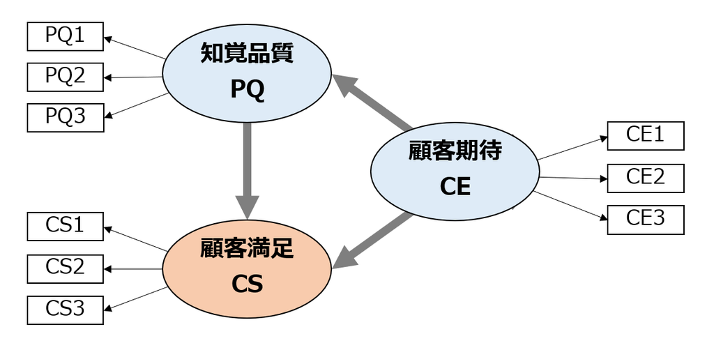